# efg’s R Notes: EBImage: Features

**RNotes | EBImage | Features**

**Basic | Haralick | Moment | Shape**

```r
library(EBImage)
```

# Image Object Features

- computeFeatures
- computeFeatures.basic
- computeFeatures.haralick
- computeFeatures.moment
- computeFeatures.shape
- standardExpandRef

## load and segment nucleus

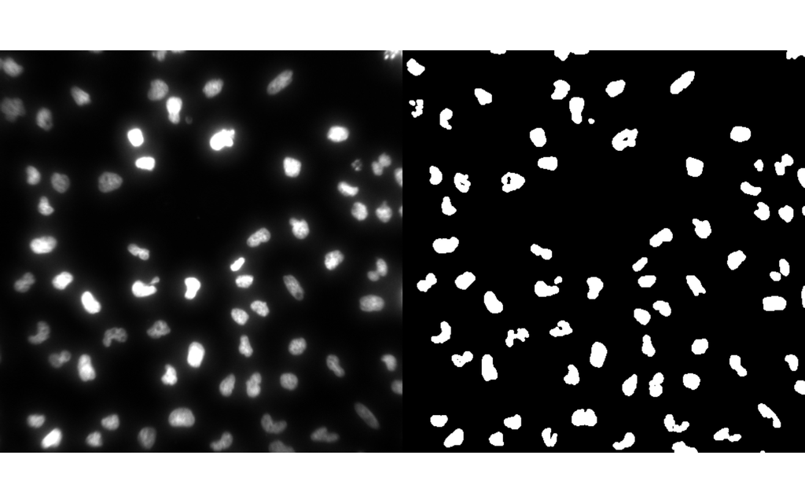

```r
par(mfrow=c(1,2))
y <- readImage(system.file("images", "nuclei.tif", package="EBImage"))[,,1]
x <- thresh(y, 10, 10, 0.05)
x <- opening(x, makeBrush(5, shape='disc'))
x <- bwlabel(x)

display(y, title="Cell nuclei")
display(x, title="Segmented nuclei")
```

## compute shape features

```r
fts <- computeFeatures.shape(x)
str(fts)
```

```
##  num [1:76, 1:6] 75 286 211 321 502 423 379 330 488 204 ...
##  - attr(*, "dimnames")=List of 2
##   ..$ : chr [1:76] "1" "2" "3" "4" ...
##   ..$ : chr [1:6] "s.area" "s.perimeter" "s.radius.mean" "s.radius.sd" ...
```

```r
fts
```

```
##    s.area s.perimeter s.radius.mean s.radius.sd s.radius.min s.radius.max
## 1      75          40      5.384756   2.5473087    1.4630875     9.598991
## 2     286          95     11.914279   6.2510079    1.6594562    22.733608
## 3     211          61      8.463546   2.8625585    3.9930738    12.369067
## 4     321          56      9.781896   1.6472487    6.2744674    12.269780
## 5     502          80     13.182665   4.1268371    6.3981687    19.601315
## 6     423          70     11.193220   2.0760003    5.6671268    14.562252
## 7     379          62     10.640572   1.6783868    7.8950748    13.529297
## 8     330          61      9.992652   1.7385299    6.7247892    13.441793
## 9     488          81     12.307053   3.3772075    6.2079250    18.124605
## 10    204          60      7.874377   2.8414135    2.3777908    12.207398
## 11     44          19      3.332189   0.4755575    2.3139945     4.095806
## 12    311          67      9.494065   3.0864776    1.5623237    13.654335
## 13     44          19      3.305533   0.3703584    2.5004155     3.864749
## 14    420          67     11.123299   1.2934341    8.6474474    13.257580
```

[output cut: 62 more lines]

Features computed by *computeFeatures.shape* are prefixed with “s.” and all are measured in pixels.

## compute features

```r
ft <- computeFeatures(x, y, xname="nucleus")
cat("median features are:\n")
```

```
## median features are:
```

```r
apply(ft, 2, median)
```

```
##            nucleus.0.m.cx            nucleus.0.m.cy
##              2.760080e+02              2.917190e+02
##     nucleus.0.m.majoraxis  nucleus.0.m.eccentricity
##              2.716022e+01              7.799645e-01
##         nucleus.0.m.theta          nucleus.0.s.area
##              6.983438e-02              3.450000e+02
##     nucleus.0.s.perimeter   nucleus.0.s.radius.mean
##              6.450000e+01              1.019973e+01
##     nucleus.0.s.radius.sd    nucleus.0.s.radius.min
##              2.245853e+00              5.135894e+00
##    nucleus.0.s.radius.max          nucleus.a.b.mean
##              1.365719e+01              5.537696e-01
##            nucleus.a.b.sd           nucleus.a.b.mad
##              1.184311e-01              1.162824e-01
##          nucleus.a.b.q001          nucleus.a.b.q005
##              3.151373e-01              3.598039e-01
##           nucleus.a.b.q05          nucleus.a.b.q095
##              5.647059e-01              7.411765e-01
##          nucleus.a.b.q099            nucleus.a.m.cx
##              7.681569e-01              2.759344e+02
##            nucleus.a.m.cy     nucleus.a.m.majoraxis
##              2.918791e+02              2.563950e+01
##  nucleus.a.m.eccentricity         nucleus.a.m.theta
##              7.673224e-01              2.233263e-02
##        nucleus.a.h.asm.s1        nucleus.a.h.con.s1
##              2.238844e-02              3.645172e+00
##        nucleus.a.h.cor.s1        nucleus.a.h.var.s1
##              8.512804e-01              1.240606e+01
##        nucleus.a.h.idm.s1        nucleus.a.h.sav.s1
##              5.039755e-01              3.630086e+01
##        nucleus.a.h.sva.s1        nucleus.a.h.sen.s1
##              1.269986e+03              1.339942e+00
##        nucleus.a.h.ent.s1        nucleus.a.h.dva.s1
##              1.816435e+00              3.645172e+00
##        nucleus.a.h.den.s1        nucleus.a.h.f12.s1
##              6.324399e-01              2.786244e-01
##        nucleus.a.h.f13.s1        nucleus.a.h.asm.s2
##              6.659335e-01              1.982790e-02
##        nucleus.a.h.con.s2        nucleus.a.h.cor.s2
##              9.450356e+00              6.010386e-01
```

[output cut: 35 more lines]

```
##              1.800243e-01              5.919088e-01
##       nucleus.Ba.h.asm.s2       nucleus.Ba.h.con.s2
##              9.993056e-03              5.253647e+01
##       nucleus.Ba.h.cor.s2       nucleus.Ba.h.var.s2
##              3.220357e-01              4.363279e+01
##       nucleus.Ba.h.idm.s2       nucleus.Ba.h.sav.s2
##              2.085173e-01              4.089912e+01
##       nucleus.Ba.h.sva.s2       nucleus.Ba.h.sen.s2
##              1.646988e+03              1.489651e+00
##       nucleus.Ba.h.ent.s2       nucleus.Ba.h.dva.s2
##              2.186038e+00              5.253647e+01
##       nucleus.Ba.h.den.s2       nucleus.Ba.h.f12.s2
##              1.126337e+00              1.735806e-01
##       nucleus.Ba.h.f13.s2
##              5.638763e-01
```

The function *computeFeatures.basic* computes spatial-independent statistics on pixel intensities that have a “b.” prefix: b.mean, b.sd, b.mad, b.q*. Intensity values range from 0.0 to 1.0.

The function *computeFeatures.moment* computes features related to object image moments, which can be computed with or without reference intensities, and have a prefix “m.”:

- center of mass: m.cx, m.cy [pixels]
- elliptical fit major axis: m.majoraxis [pixels]
- elliptical eccentricity: m.eccentricity [dimensionless] (0=circle, 1=straight line)
- object angle [radians]: m.theta

The function *computeFeatures.haralick* computes features that quantify pixel texture. Features are named according to Haralick’s original paper, [Textural Features for Image Classification](http://www.haralick.org/journals/TexturalFeatures.pdf). Haralick texture features have a prefix “h.”.

Texture features in EBImage are calculated according to a Gray-Level Co-occurrence Matrix (GLCM) using the mean intensity of the pixel’s 4 neighboring pixels (0°, 45°, 90°, and 135°) according to [Aleksi Räsänen et al](https://jyx.jyu.fi/dspace/bitstream/handle/123456789/43899/uvaikkariobiaii.pdf?sequence=1): *The GLCM features estimate different features of pixel brightness value combinations from the neighboring pixels. Overall, 13 GLCM features given by Haralick et al. (1973) were calculated: angular second moment (asm), contrast (con), correlation (cor), variance (var), inverse difference moment (idm), sum average (sav), sum variance (sva), sum entropy (sen), entropy (ent), difference variance (dva), difference entropy (den), and two measures of correlation (f12 and f13). For the GLCM calculations, the pixel brightness values were quantized to 16 gray levels using equal intervals.*

## compute feature properties

```r
ftp <- computeFeatures(x, y, properties=TRUE, xname="nucleus")
ftp
```

```
##                         name translation.invariant rotation.invariant
## 1             nucleus.0.m.cx                 FALSE               TRUE
## 2             nucleus.0.m.cy                 FALSE               TRUE
## 3      nucleus.0.m.majoraxis                  TRUE               TRUE
## 4   nucleus.0.m.eccentricity                  TRUE               TRUE
## 5          nucleus.0.m.theta                  TRUE              FALSE
## 6           nucleus.0.s.area                  TRUE               TRUE
## 7      nucleus.0.s.perimeter                  TRUE               TRUE
## 8    nucleus.0.s.radius.mean                  TRUE               TRUE
## 9      nucleus.0.s.radius.sd                  TRUE               TRUE
## 10    nucleus.0.s.radius.min                  TRUE               TRUE
## 11    nucleus.0.s.radius.max                  TRUE               TRUE
## 12          nucleus.a.b.mean                  TRUE               TRUE
## 13            nucleus.a.b.sd                  TRUE               TRUE
## 14           nucleus.a.b.mad                  TRUE               TRUE
```

[output cut: 75 more lines]

Related: Slides 13-22 in Wolfgang Huber’s presentation [Machine learning in high-throughput screening and automated phenotyping](http://mlpm.eu/static/media/uploads/mlpm13_slides_huber01.pdf) [~35 MB].

```r
packageVersion("EBImage")
```

```
## [1] '4.8.2'
```

*efg*  
2015-01-19 1926